# Analyse comparative des consommations energetiques - DPE

De Franceschi Lucas / Nugier Louis / Cerqueira Gregory

2025-11-16

# Introduction

La transition énergétique et la maîtrise de la consommation des logements sont des enjeux majeurs face aux défis climatiques et à la hausse des coûts de l’énergie.  
Ce rapport, réalisé dans le cadre du projet *Enedis*, vise à étudier l’association entre la **classe DPE** (Diagnostic de Performance Énergétique) et la **consommation d’énergie primaire** (kWh/m²/an) sur trois départements du massif central : **Creuse (23)**, **Corrèze (19)** et **Haute‑Vienne (87)**.

# Méthodologie et données

**Source des données** : jeux DPE fournis par l’API ADEME (jeu `dpe03existant`).

**Variables principales utilisées** : - `code_departement_ban` : code du département (23, 19, 87)  
- `type_batiment` : type du logement (maison / appartement)  
- `etiquette_dpe` : classe DPE (A → G)  
- `etiquette_ges` : classe GES (A → G)  
- `conso_5_usages_par_m2_ep` : consommation énergie primaire (kWh/m²/an)  
- `surface_habitable_logement` : surface (m²)  
- `annee_construction` : année de construction  
- `_geopoint` : géolocalisation (latitude,longitude)

**Prétraitement** : typage numérique des variables pertinentes, retrait des valeurs absentes/non valides sur la consommation, création éventuelle d’agrégats par commune et découpage temporel par période de construction. Pour les nuages de points séléction sur 80% des données pour une meilleure lecture et outliers non présent sur les boxplots.

Indicateurs synthétiques pour les départements analysés

| conso_moy_KWh_m2_an | conso_med_KWh_m2_an | surface_moy_m2 |
| --- | --- | --- |
| 270.3 | 244 | 80.7 |

# Résultats

## 1. Répartition des classes DPE par département

La figure suivante compare la part relative de chaque classe DPE entre les départements étudiés. Cette comparaison met en évidence d’éventuelles différences structurelles du parc (ex. part plus élevée de classes défavorables).

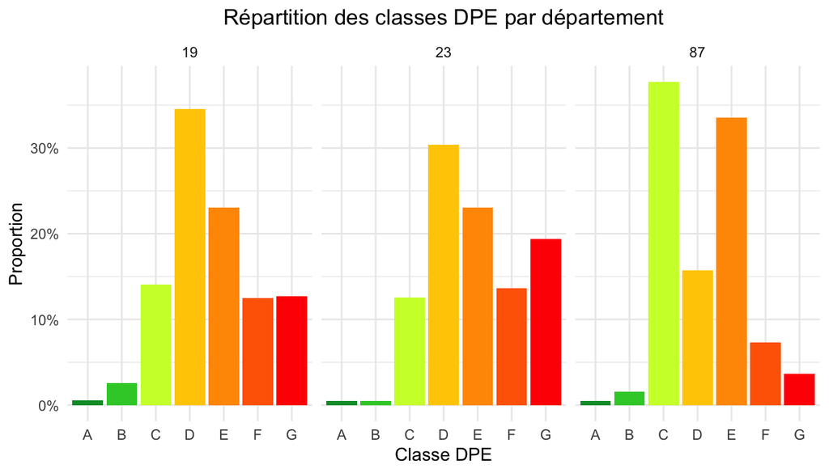

Répartition des classes DPE — comparaison 23 / 19 / 87

**Interprétation (bref)** : si un département présente proportionnellement plus de classes D–G, cela suggère un parc plus énergivore qui peut nécessiter prioritairement des actions d’amélioration énergétique.